[figure not shown]

# Weekly Statistics

Siaya County - Enterprise Sample

### Operations

**Enterprises operating each week**

[interactive chart not shown]

February, March and April data points assume that no business that closed down up until that point reopened, and they correspond to the first day of each month.

**Total hours worked by all employees - past 7 days**

[interactive chart not shown]

**Closures by month relative to February’s operation levels**

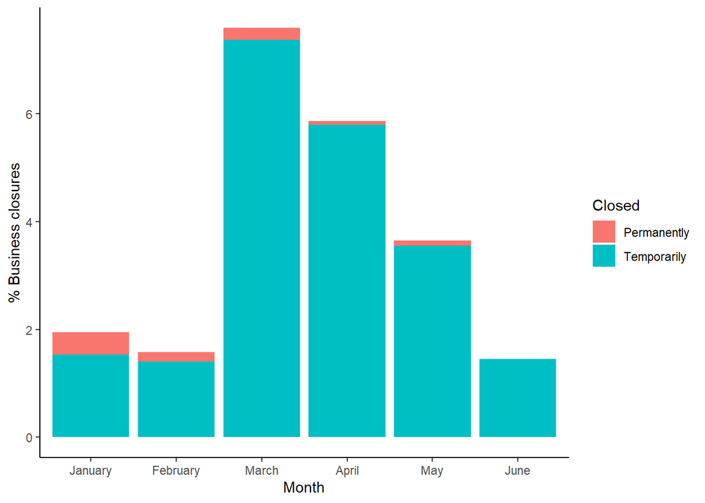

### Revenue and profit

**Enterprises revenue and profits - past 14 days**

[interactive chart not shown]

**Revenue by sector - past 14 days (2 week average)**

[interactive chart not shown]

*Agriculture is normalized by last year’s 2-week typical revenue, while all other variables are normalized by the average reported revenue for February. Reported amounts were averaged every two weeks.

### Investment and wages

**Investment (USD, PPP) - past 14 days**

[interactive chart not shown]

**Wages (USD, PPP) - past 14 days**

[interactive chart not shown]

### COVID-19 Impact

**COVID-19 Impact**

How has COVID-19 affected this business?*

[interactive chart not shown]

*This is for the proportion of enterprises currently operating.

**Number of customers - past 7 days**

[interactive chart not shown]

### COVID-19 Prevention

**Enterprises reporting a preventive change in their business model**

Percentage of enterprises that reported a change in their business model since March 2020 to reduce the risk of employees spreading or contracting the virus as well as changes that reduce customer interactions.

[interactive chart not shown]

**Percentage of businesses with employees working from home**

[interactive chart not shown]

**Mobile Payments**

Percentage of firms accepting mobile payments and their share among firms that accept mobile payments.

[interactive chart not shown]

### Layoffs

**Temporal distribution of layoffs relative to February’s employment level**

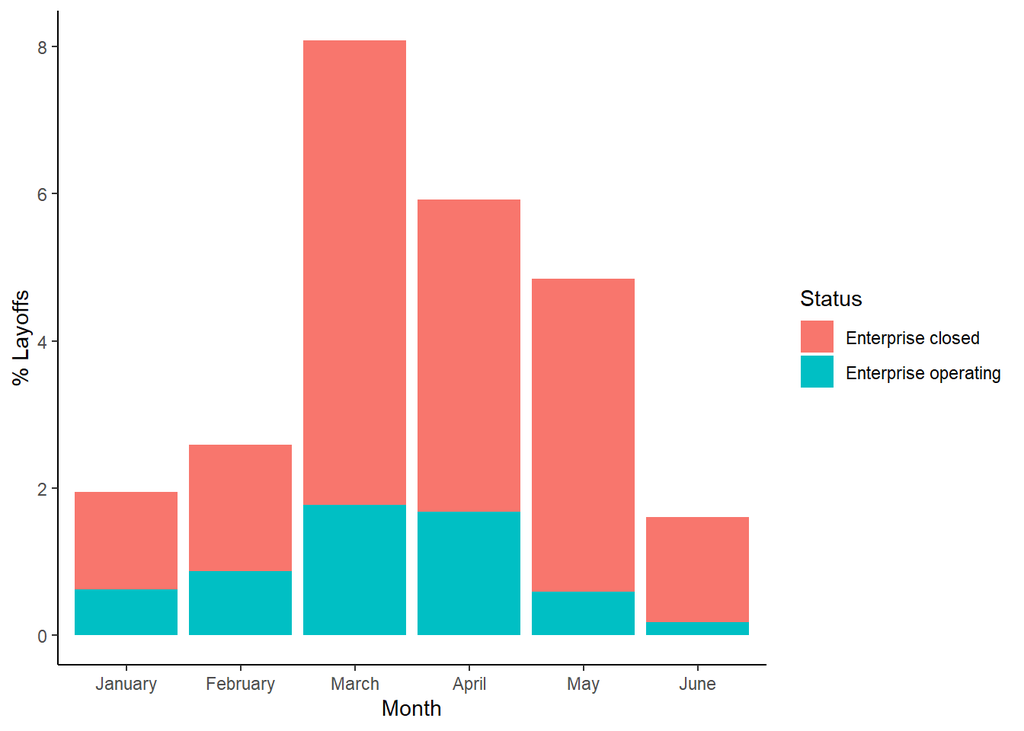

These data comes from phone survey interviews conducted by [REMIT Kenya](http://remitkenya.co.ke/) in Siaya County, Kenya. We are collecting data for a sample of ~5,000 enterprises in the county, which is representative of the whole population of enterprises. At the same time, our weekly sampling method assures weekly representativeness of the overall sample.

| Week | Dates | Number of surveys | Round |
| --- | --- | --- | --- |
| Week 1 | 10 May 2020 - 16 May 2020 | 532 | 1 |
| Week 2 | 17 May 2020 - 23 May 2020 | 458 | 1 |
| Week 3 | 24 May 2020 - 30 May 2020 | 434 | 1 |
| Week 4 | 31 May 2020 - 06 June 2020 | 732 | 1 |
| Week 5 | 07 June 2020 - 13 June 2020 | 885 | 1 |
| Week 6 | 14 June 2020 - 20 June 2020 | 1216 | 1 |
| Week 9 | 5 July 2020 - 11 July 2020 | 569 | 2 |
| Week 10 | 12 July 2020 - 18 July 2020 | 608 | 2 |
| Week 11 | 19 July 2020 - 25 July 2020 | 550 | 2 |
| Week 12 | 26 July 2020 - 01 August 2020 | 615 | 2 |
| Week 13 | 02 August 2020 - 08 August 2020 | 629 | 2 |